# EkonomiaWTrakcieWojny

## Model ekonomiczny państwa podczas wojny

[figure not shown]

```python
from IPython.display import Image
Image("economy_photo1.jpg")
```

## Wojna dwóch ekonomicznych potęg

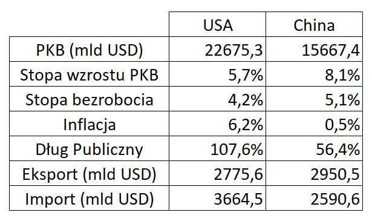

```python
Image("economy_zestawienie_USA_Chiny.jpg")
```

## Regresja

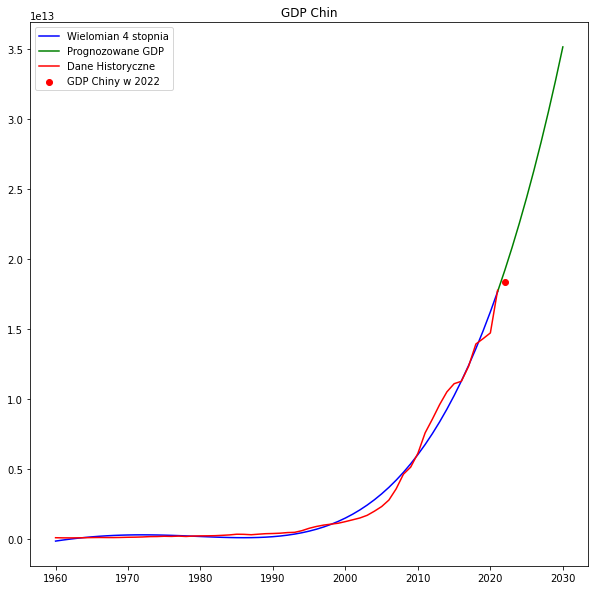

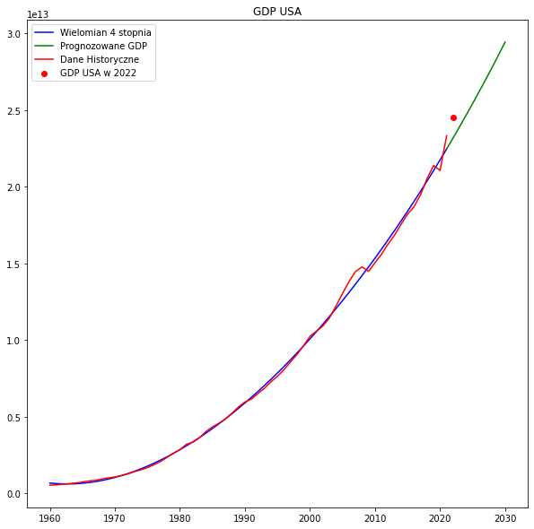

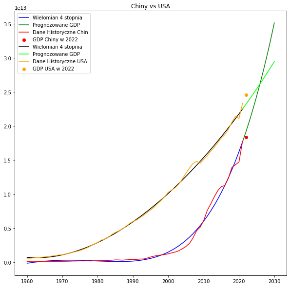

```
2025.9271812002148
2027.2837927375929
```

```python
import numpy as np
import matplotlib.pyplot as plt
import csv

with open('GDP.csv', 'r') as file:
    reader = csv.reader(file,delimiter='\n')
    dane=[]
    for row in reader:
        dane.append(row[0].split(","))
dane_chiny=dane[41][4:-1]
dane_chiny_l=[]
daty=[]
for i in range(len(dane_chiny)):
    daty.append(1960+i)

for i in dane_chiny:

    dane_chiny_l.append(float(i[1:-1]))

dane_usa=dane[252][4:-1]
dane_usa_l=[]
for i in dane_usa:
    dane_usa_l.append(float(i[1:-1]))
dane_chiny_l=dane_chiny_l
dane_usa_l=dane_usa_l
x=daty
cof=np.polyfit(daty,dane_chiny_l,4)
yd=[cof[0]*i**4+cof[1]*i**3+cof[2]*i**2+cof[3]*i+cof[4] for i in x]

x_prog_ch=[2021,2022,2023,2024,2025,2026,2027,2028,2029,2030]
y_prog_ch=[cof[0]*i**4+cof[1]*i**3+cof[2]*i**2+cof[3]*i+cof[4] for i in x_prog_ch]
plt.figure(figsize=(10,10))
plt.plot(x, yd, color="blue",label="Wielomian 4 stopnia")
plt.plot(x_prog_ch, y_prog_ch, color="green",label="Prognozowane GDP")
plt.plot(daty, dane_chiny_l,color="red",label="Dane Historyczne")
plt.scatter([2022],[18321000000000],label="GDP Chiny w 2022",color="red")
plt.title("GDP Chin")
plt.legend()
plt.show()

cof_usa=np.polyfit(daty,dane_usa_l,4)
yd_us=[cof_usa[0]*i**4+cof_usa[1]*i**3+cof_usa[2]*i**2+cof_usa[3]*i+cof_usa[4] for i in x]
x_prog_us=[2021,2022,2023,2024,2025,2026,2027,2028,2029,2030]
y_prog_us=[cof_usa[0]*i**4+cof_usa[1]*i**3+cof_usa[2]*i**2+cof_usa[3]*i+cof_usa[4] for i in x_prog_us]
plt.figure(figsize=(10,10))
plt.plot(x, yd_us, color="blue",label="Wielomian 4 stopnia")
plt.plot(x_prog_us, y_prog_us, color="green",label="Prognozowane GDP")
plt.plot(daty,dane_usa_l,color="red",label="Dane Historyczne")
plt.scatter([2022],[24535000000000],label="GDP USA w 2022",color="red")
plt.title("GDP USA")
plt.legend()
plt.show()

x=daty
cof=np.polyfit(daty,dane_chiny_l,4)
yd=[cof[0]*i**4+cof[1]*i**3+cof[2]*i**2+cof[3]*i+cof[4] for i in x]

x_prog_ch=[2021,2022,2023,2024,2025,2026,2027,2028,2029,2030]
y_prog_ch=[cof[0]*i**4+cof[1]*i**3+cof[2]*i**2+cof[3]*i+cof[4] for i in x_prog_ch]
plt.figure(figsize=(10,10))
plt.plot(x, yd, color="blue",label="Wielomian 4 stopnia")
plt.plot(x_prog_ch, y_prog_ch, color="green",label="Prognozowane GDP")
plt.plot(daty, dane_chiny_l,color="red",label="Dane Historyczne Chin")
plt.scatter([2022],[18321000000000],label="GDP Chiny w 2022",color="red")
plt.title("Chiny vs USA")

cof_usa=np.polyfit(daty,dane_usa_l,4)
yd_us=[cof_usa[0]*i**4+cof_usa[1]*i**3+cof_usa[2]*i**2+cof_usa[3]*i+cof_usa[4] for i in x]
x_prog_us=[2021,2022,2023,2024,2025,2026,2027,2028,2029,2030]
y_prog_us=[cof_usa[0]*i**4+cof_usa[1]*i**3+cof_usa[2]*i**2+cof_usa[3]*i+cof_usa[4] for i in x_prog_us]
plt.plot(x, yd_us, color="black",label="Wielomian 4 stopnia")
plt.plot(x_prog_us, y_prog_us, color="lime",label="Prognozowane GDP")
plt.plot(daty,dane_usa_l,color="orange",label="Dane Historyczne USA")
plt.scatter([2022],[24535000000000],label="GDP USA w 2022",color="orange")
plt.legend()
plt.show()

cof_zerowe=[cof[i]-cof_usa[i] for i in range(5)]
print(np.real(np.roots(cof_zerowe)[0]))

daty.append(2022)
dane_usa_l.append(24535000000000)
dane_chiny_l.append(18321000000000)
cof=np.polyfit(daty,dane_chiny_l,4)
cof_usa=np.polyfit(daty,dane_usa_l,4)
cof_zerowe=[cof[i]-cof_usa[i] for i in range(5)]
print(np.real(np.roots(cof_zerowe)[0]))
```

## Solow-Swan model

Jest to ekonomiczny model opisujący długoterminowy wzrost gospodarczy państwa. Został on opracowany przez Roberta Solowa i Trevora Swana w latach 50 XX. wieku. Model zakłada, że wzrost gospodarczy jest spowodowany przez akumulacje kapitału, wzrost populacji oraz wzrost produktywności będący wynikiem postępu technologicznego, natomiast nie uwzględnia handlu międzynarodowego czy zmian politycznych.

Matematyczny model wygląda następująco:

$$Y(t) = K(t)^\alpha(A(t)L(t))^{1-\alpha},$$

gdzie:  
Y - Ogólna produkcja  
A - Postęp technologiczny  
L - Siła robocza  
AL - Efektywna siła robocza  
K - Kapitał  
$\alpha$ - Elastyczność produkcji

Dynamika powyższego modelu jest opisana równaniem: $$\frac{dK}{dt} = sY(t) - \delta K(t),$$ gdzie:
$\delta$ - Stała odpowiadająca za obniżenie wartości kapitału
$s = 1-c$ - część kapitału służąca do inwestycji, gdzie
$0 < c < 1$ - zużywana część kapitału

## Własny model

$$GDP = C + I + G + T$$

Gdzie:  
GDP - Produkt krajowy brutto  
C - Konsumpcja prywatna  
I - Inwestycje prywatne  
G - Wydatki rządowe  
T - Bilans handlowy (eksport minus import)

$C' = aC - bGDP$  
$I' = cT - dI$  
$G' = eG$  
$GDP' = fC + gI + hG + kT$  
$T = GDP - C - I - G$

```python
# Chyba ok współczynniki na czas pokoju

Cu, Iu, Gu, Tu = [15.36], [4.36], [4.04], [-0.70]
au, bu, cu, du, eu, fu, gu, hu, ku = 0.06, 0.02, 0.02, 0.01, 0.01, 0.03, 0.02, 0.01, -0.005
Cc, Ic, Gc, Tc = [9.33], [5.67], [0.67], [0.06]
ac, bc, cc, dc, ec, fc, gc, hc, kc = 0.05, 0.001, 0.03, 0.005, 0.03, 0.1, 0.04, 0.02, 0.2
GDPu = [23.06]
GDPc = [15.73]

for i in range(1, 10):
    dCu = au * Cu[i-1] - bu * GDPu[i-1]
    dIu = cu * GDPu[i-1] - du * Iu[i-1]
    dGu = eu * Gu[i-1]
    dTu = 0
    dGDPu = fu * Cu[i-1] + gu * Iu[i-1] + hu * Gu[i-1] + ku * Tu[i-1]
    Cu.append(Cu[i-1] + dCu)
    Iu.append(Iu[i-1] + dIu)
    Gu.append(Gu[i-1] + dGu)
    #Tu.append(Tu[i-1] + dTu)
    GDPu.append(GDPu[i-1] + dGDPu)
    Tu.append(GDPu[i] - Cu[i] - Iu[i] - Gu[i])

    dCc = ac * Cc[i-1] - bc * GDPc[i-1]
    dIc = cc * GDPc[i-1] - dc * Ic[i-1]
    dGc = ec * Gc[i-1]
    dTc = 0
    dGDPc = fc * Cc[i-1] + gc * Ic[i-1] + hc * Gc[i-1] + kc * Tc[i-1]
    Cc.append(Cc[i-1] + dCc)
    Ic.append(Ic[i-1] + dIc)
    Gc.append(Gc[i-1] + dGc)
    #Tu.append(Tu[i-1] + dTu)
    GDPc.append(GDPc[i-1] + dGDPc)
    Tc.append(GDPc[i] - Cc[i] - Ic[i] - Gc[i])

    if Cu[i] <= 2.1 or Cc[i] <= 1.2: # zbyt mała konsumpcja na kontynuacje wojny
        break;
    if Iu[i] <= 0 or Ic[i] <= 0: # zbyt mała produkcja na kontynuacje wojny
        break;
    if Gu[i] <= -2 or Gc[i] <= -2: # zbyt duże rośnięcie długu publicznego
        break;

    GDPu_peace, GDPc_peace = GDPu, GDPc
```

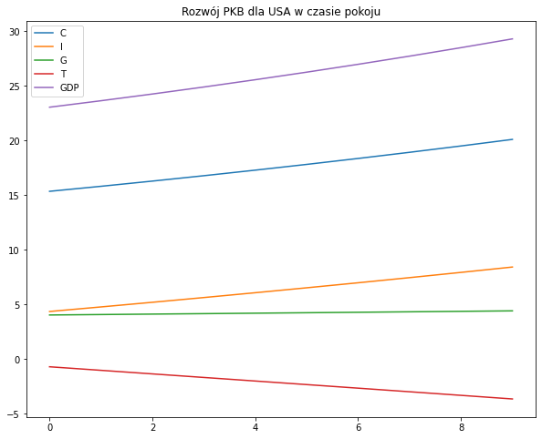

```python
plt.figure(figsize=(10,8))
plt.title("Rozwój PKB dla USA w czasie pokoju")
plt.plot(Cu, label="C")
plt.plot(Iu, label="I")
plt.plot(Gu, label="G")
plt.plot(Tu, label="T")
plt.plot(GDPu, label="GDP")
plt.legend()
```

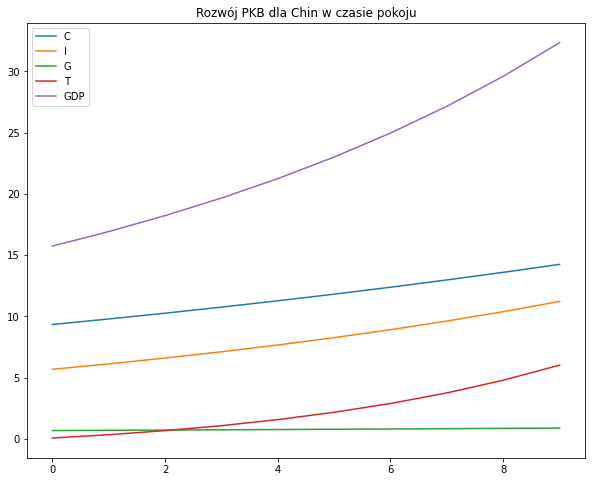

```python
plt.figure(figsize=(10,8))
plt.title("Rozwój PKB dla Chin w czasie pokoju")
plt.plot(Cc, label="C")
plt.plot(Ic, label="I")
plt.plot(Gc, label="G")
plt.plot(Tc, label="T")
plt.plot(GDPc, label="GDP")
plt.legend()
```

```python
# Współczynniki w czasie wojny

Cu, Iu, Gu, Tu = [15.36], [4.36], [4.04], [-0.70]
au, bu, cu, du, eu, fu, gu, hu, ku = 0.01, 0.04, 0.001, 0.01, 0.1, 0.06, 0.03, 0.01, 0.01
Cc, Ic, Gc, Tc = [9.33], [5.67], [0.67], [0.06]
ac, bc, cc, dc, ec, fc, gc, hc, kc = 0.03, 0.05, 0.03, 0.005, 0.12, 0.05, 0.02, 0.01, 0.2
GDPu = [23.06]
GDPc = [15.73]

# dodatkowe współczynniki dla spadku handlu
USA_handel = -1.3
Chiny_handel = -0.65

for i in range(1, 10):
    dCu = au * Cu[i-1] - bu * GDPu[i-1]
    dIu = cu * GDPu[i-1] - du * Iu[i-1]
    dGu = eu * Gu[i-1]
    dTu = 0
    dGDPu = fu * Cu[i-1] + gu * Iu[i-1] + hu * Gu[i-1] + ku * Tu[i-1] + USA_handel
    Cu.append(Cu[i-1] + dCu)
    Iu.append(Iu[i-1] + dIu)
    Gu.append(Gu[i-1] + dGu)
    #Tu.append(Tu[i-1] + dTu)
    GDPu.append(GDPu[i-1] + dGDPu)
    Tu.append(GDPu[i] - Cu[i] - Iu[i] - Gu[i])

    dCc = ac * Cc[i-1] - bc * GDPc[i-1]
    dIc = cc * GDPc[i-1] - dc * Ic[i-1]
    dGc = ec * Gc[i-1]
    dTc = 0
    dGDPc = fc * Cc[i-1] + gc * Ic[i-1] + hc * Gc[i-1] + kc * Tc[i-1] + Chiny_handel
    Cc.append(Cc[i-1] + dCc)
    Ic.append(Ic[i-1] + dIc)
    Gc.append(Gc[i-1] + dGc)
    #Tu.append(Tu[i-1] + dTu)
    GDPc.append(GDPc[i-1] + dGDPc)
    Tc.append(GDPc[i] - Cc[i] - Ic[i] - Gc[i])
```

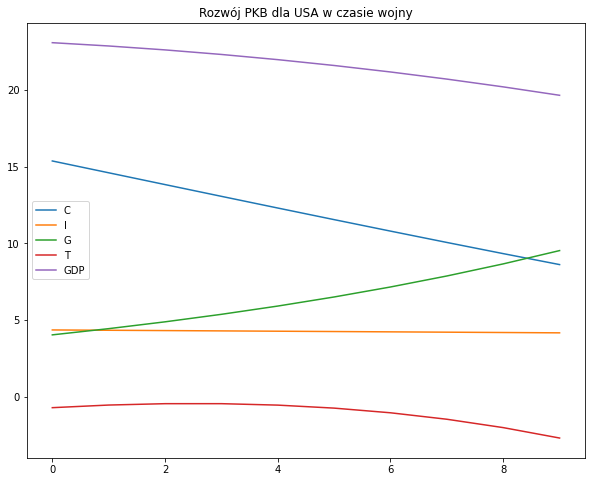

```python
plt.figure(figsize=(10,8))
plt.title("Rozwój PKB dla USA w czasie wojny")
plt.plot(Cu, label="C")
plt.plot(Iu, label="I")
plt.plot(Gu, label="G")
plt.plot(Tu, label="T")
plt.plot(GDPu, label="GDP")
plt.legend()
```

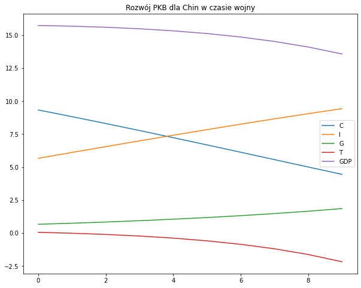

```python
plt.figure(figsize=(10,8))
plt.title("Rozwój PKB dla Chin w czasie wojny")
plt.plot(Cc, label="C")
plt.plot(Ic, label="I")
plt.plot(Gc, label="G")
plt.plot(Tc, label="T")
plt.plot(GDPc, label="GDP")
plt.legend()
```

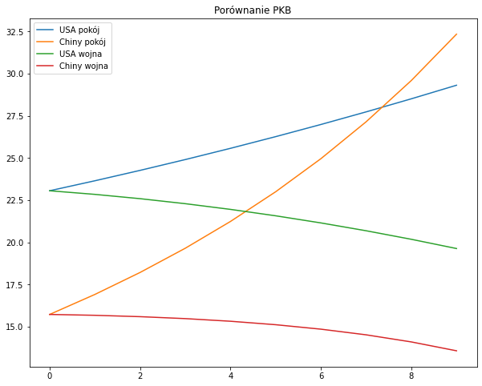

```python
plt.figure(figsize=(10,8))
plt.title("Porównanie PKB")
plt.plot(GDPu_peace, label="USA pokój")
plt.plot(GDPc_peace, label="Chiny pokój")
plt.plot(GDPu, label="USA wojna")
plt.plot(GDPc, label="Chiny wojna")
plt.legend()
```

# 5.KISS (Keep It Simple Stupid)

$$GDP = C + I + G + T$$

## 5.1 $C$ - konsumpcja prywatna

$$C = a + b(Y-T)$$

$Y$ - dochód narodowy  
$T$ - podatki  
$a$ - stała składowa określająca poziom wydatków konsumpcyjnych gdy dochów jest równy zero (zmniejszona z powodu wojny)  
$b$ - współczynnik który określa, jak bardzo wzrost dochodu wpłynie na wydatki konsumpcyjne (w czasie wojny wpływ wzrostu bezrobocia na wydatki konsumpcyjne)

## 5.2 $G$ - wydatki rządowe

$$G = \alpha * (Y - Z) - \beta * (T - ZT)$$

$Y$ - funkcja produkcji  
$\alpha$ - Stały współczynnik proporcjonalności, który określa, jak bardzo poziom wydatków rządowych zależy od poziomu produkcji  
$\beta$ - Stały współczynnik proporcjonalności, który określa, jak bardzo poziom wydatków rządowych zależy od stopy podatkowej  
$Z$ - Dodatkowe wydatki zwiazane z wojną  
$T$ - poziom dochodów podatkowych

## 5.3 $T$ - bilans handlowy

$$T = (PEX * QEX * PEX_R) - (PIM * QIM * PIM_R) - CC$$

$PEX$ - cena eksportowanych towarów  
$QEX$ - ilość eksportowanych towarów  
$PEX_R$ - współczynnik elastyczności cenowej eksportu  
$PIM$ - cena importowanych towarów  
$QIM$ - ilość importowanych towarów  
$PIM_R$ - współczynnik elastyczności cenowej importu  
$CC$ - wartość ceł i innych ograniczeń w handlu

## 5.4 $I$ - inwestycje prywatne

$$I(t) = k * (Y(t) - Y(t-1)) - F(K(t), L(t)) * (1 - IZ)$$

$k$ - stały współczynnik akceleracji , który określa, jak bardzo zmiana produkcji wpłynie na poziom inwestycji  
$Y(t)$ - funkcja produkcji w t okresie czasowym  
$F(K(t), L(t))$ - funkcja produkcji militarnej w t okresie czasowym  
$IZ$ - współczynnik inwestycji zagranicznych

### $Y(t)$ - funkcja produkcji

$$Y(t) = Q(t) * a$$

$Q(t)$ - funkcja ilości wyprodukowanych dóbr i usług w t okresie czasowym  
$a$ - stała proporcjonalności (tj. cena jednostkowa produktu)

#### $Q(t)$ - funkcja ilości wyprodukowanych dóbr i usług

$$Q(t) = A * K(t)^\alpha * L(t)^\beta$$

$K(t)$ - ilość kapitału poświęcanego na produkcję w t okresie czasowym  
$L(t)$ - ilość pracowników w t okresie czasowym  
$A$ - wskaźnik zaawansowania technologiczngo  
$\alpha$ - parametr określający wpływ kapitału na produkcję  
$\beta$ - parametr określający wpływ liczby pracowników na produkcję

##### $L(t)$ - funkcja ilości pracowników

$$dL(t)/dt = r*L(t)*(1-L(t)/K)$$

$dL(t)/dt$ - szybkość zmian w liczbie osobników populacji w czasie  
$r$ - szybkość wzrostu populacji \ szybkość wzrostu ilości pracowników  
$P$ - aktualna liczba osobników w populacji \ aktualna liczba pracowników  
$K$ - pojemność środowiska \ maksymalna liczba stanowisk produkcyjnych

$$dL(t)/dt = r*L(t) - d*L(t)$$

$dL(t)/dt$ - szybkość zmian w liczbie osobników populacji w czasie  
$r$ - wspólczynnik urodzeń \ wzrostu liczby pracowników  
$d$ - współczynnik śmierci \ emigracji pracowników

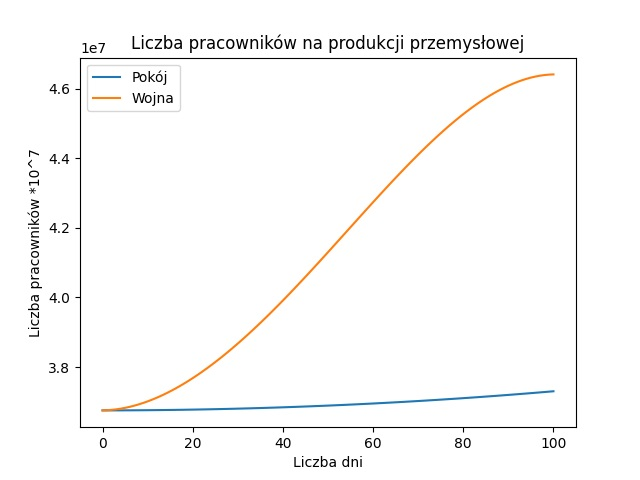

```python
Image("economy_pracownicy_produkcja.jpg")
```